# Project 4

Cesar L. Espitia

4/16/2017

## Summary

This project involves predicting whether an email is SPAM or HAM using the `tm` and `RTextTools` packages.

The folders downloaded from **https://spamassassin.apache.org/publiccorpus/**. The file `20030228_easy_ham.tar.bz2` and `20050311_spam_2.tar.bz2` are being used for this analysis.

## Setup

The following packages were used in this analysis: `stringer, dplyr, tm, RTextTools, ggplot, DT, ROCR and wordcloud`.

```cpp
library(stringr)
library(dplyr)
library(tm)
library(RTextTools)
library(wordcloud)
library(DT)
library(ROCR)
library(ggplot2)
library(SDMTools)
library(pROC)

#Obtain current working directory.
setwd("~/Documents/CUNYMSDA/Data 607/CUNYDATA607/Project 4")
```

## Building the Corpus

Used VCorpus to build the junk and good emails into spearte corpus. The meta headers of each email was then converted to either 0 or 1 to determine if they were good emails or junk emails.

There are 1397 files from the spam file and 2501 from the ham file.

```cpp
projectjunk <- VCorpus(DirSource("spam_2"))
projectgood <- VCorpus(DirSource("easy_ham"))

## update headers into 1 and 0 to differentiate for processing
meta(projectjunk, "spam") <- 1
meta(projectgood, "spam") <- 0

projectall <- c(projectjunk, projectgood)
```

## Cleanup and Transformatino of the Corpus

The following steps set everything to lowercase, remove any numbers, remove english stop words (built into tm) and remove all non-alpha numeric characters. This was directly from some items found in the Data Collection with R.

```cpp
projectall <- tm_map(projectall, content_transformer(function(x) iconv(x, to = 'UTF-8-MAC', sub = 'byte')))
projectall <- tm_map(projectall, content_transformer(tolower))
projectall <- tm_map(projectall, removeNumbers)
projectall <- tm_map(projectall, removeWords, words = stopwords("en"))
projectall <- tm_map(projectall, content_transformer(function(x) str_replace_all(x, "[[:punct:]]|<|>", " ")))
projectall <- tm_map(projectall, stripWhitespace)
```

## Sampling and Seeds

The following section generates the training and test sets from the same files instead of using separate file contents.

RTextTools are then used to determine how good the model is at predicting.

```cpp
projectall <- tm_map(projectall, content_transformer(function(x) iconv(x, to = 'UTF-8-MAC', sub = 'byte')))
projectall <- tm_map(projectall, content_transformer(tolower))
projectall <- tm_map(projectall, removeNumbers)
projectall <- tm_map(projectall, removeWords, words = stopwords("en"))
projectall <- tm_map(projectall, content_transformer(function(x) str_replace_all(x, "[[:punct:]]|<|>", " ")))
projectall <- tm_map(projectall, stripWhitespace)
```

Table 1. Percent Split Between Training and Testing Data

[output not shown]

[output not shown]

[output not shown]

## Analysis

This means that the Maxent model produces the least amount of Type I and Type II errors.

Since maxent was the best predictor you will notice in the plots that it is nearly a right triangle to show its accuracy. You will notice SVM and Tree with less pronounced vertices.

```cpp
projectall <- tm_map(projectall, content_transformer(function(x) iconv(x, to = 'UTF-8-MAC', sub = 'byte')))
projectall <- tm_map(projectall, content_transformer(tolower))
projectall <- tm_map(projectall, removeNumbers)
projectall <- tm_map(projectall, removeWords, words = stopwords("en"))
projectall <- tm_map(projectall, content_transformer(function(x) str_replace_all(x, "[[:punct:]]|<|>", " ")))
projectall <- tm_map(projectall, stripWhitespace)
```

```r
confusion.matrix(results$spam, maxent_out[,1])
```

```
##     obs
## pred    0   1
##    0 1507   7
##    1   11 873
## attr(,"class")
## [1] "confusion.matrix"
```

```r
confusion.matrix(results$spam, svm_out[,1])
```

```
##     obs
## pred    0   1
##    0 1488  10
##    1   30 870
## attr(,"class")
## [1] "confusion.matrix"
```

```r
confusion.matrix(results$spam, tree_out[,1])
```

```
##     obs
## pred    0   1
##    0 1501  24
##    1   17 856
## attr(,"class")
## [1] "confusion.matrix"
```

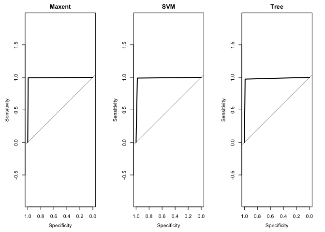

```r
par(mfrow=c(1,3))
plot(roc(results$spam, as.numeric(as.character(maxent_out[,1]))), main="Maxent")
plot(roc(results$spam, as.numeric(as.character(svm_out[,1]))), main="SVM")
plot(roc(results$spam, as.numeric(as.character(tree_out[,1]))), main="Tree")
```